# Assignment 1

### 1. Histogram of Fulfilment Speed

This chart shows the distribution of fulfillment speeds. With a few exceptions, there is a approximately 20 occurrences in the dataset.

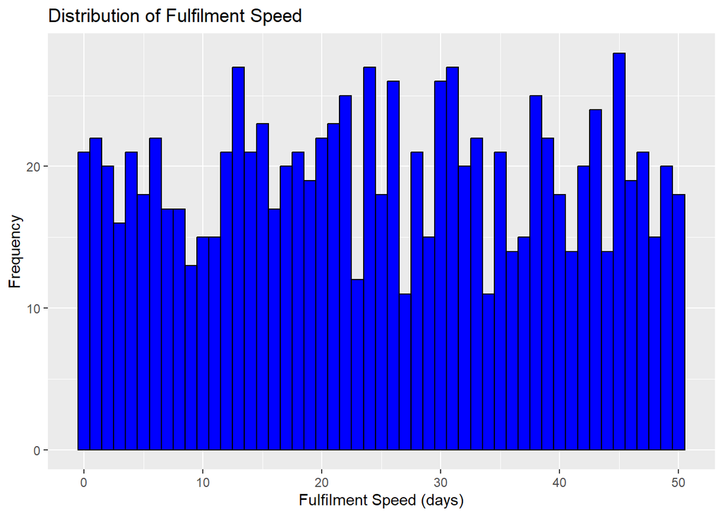

```r
ggplot(sales_1000, aes(x = Fulfilment_Speed)) +
  geom_histogram(binwidth = 1, fill = "blue", color = "black") +
  labs(title = "Distribution of Fulfilment Speed", x = "Fulfilment Speed (days)", y = "Frequency")
```

###2. Bar Plot of Item Types

This chart shows the count of each item type.

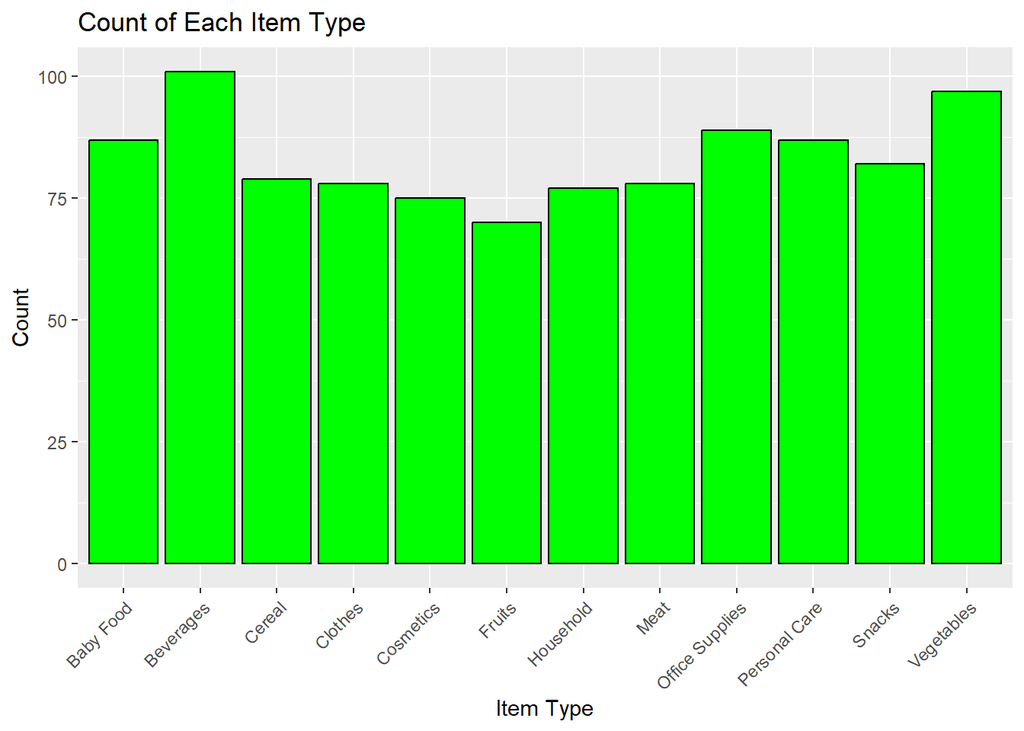

```r
ggplot(sales_1000, aes(x = Item.Type)) +
  geom_bar(fill = "green", color = "black") +
  labs(title = "Count of Each Item Type", x = "Item Type", y = "Count") +
  theme(axis.text.x = element_text(angle = 45, hjust = 1))
```

###3. Box Plot of Unit Price by Sales Channel

This chart compares the distribution of unit prices across different sales channels.

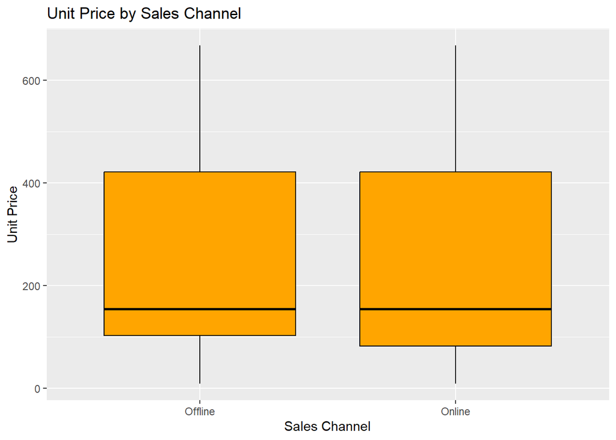

```r
ggplot(sales_1000, aes(x = Sales.Channel, y = Unit.Price)) +
  geom_boxplot(fill = "orange", color = "black") +
  labs(title = "Unit Price by Sales Channel", x = "Sales Channel", y = "Unit Price")
```

###4. Scatter Plot of Total Revenue vs. Total Profit

This chart shows the relationship between total revenue and total profit.

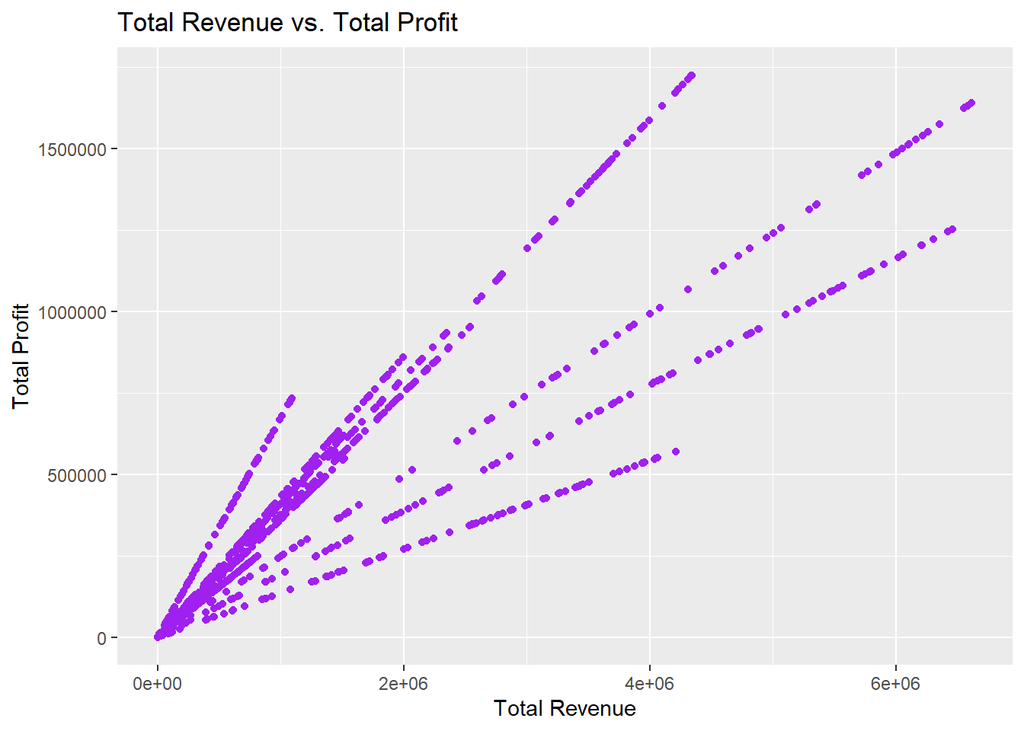

```r
ggplot(sales_1000, aes(x = Total.Revenue, y = Total.Profit)) +
  geom_point(color = "purple") +
  labs(title = "Total Revenue vs. Total Profit", x = "Total Revenue", y = "Total Profit")
```

#MODEL

```r
model_sales <- lm(Fulfilment_Speed ~ Order.Priority + Region + Total.Revenue + Sales.Channel, data = sales_1000)
```

##Model Summary

```r
summary(model_sales)
```

```
##
## Call:
## lm(formula = Fulfilment_Speed ~ Order.Priority + Region + Total.Revenue +
##     Sales.Channel, data = sales_1000)
##
## Residuals:
##      Min       1Q   Median       3Q      Max
## -28.3071 -11.7424   0.0249  12.3163  27.9851
##
## Coefficients:
##                                           Estimate Std. Error t value Pr(>|t|)
## (Intercept)                              2.606e+01  1.607e+00  16.214  < 2e-16
## Order.PriorityH                          2.947e+00  1.322e+00   2.229  0.02605
## Order.PriorityL                          5.043e-01  1.273e+00   0.396  0.69200
## Order.PriorityM                          6.961e-01  1.298e+00   0.536  0.59197
## RegionAustralia and Oceania             -2.197e+00  2.062e+00  -1.065  0.28699
## RegionCentral America and the Caribbean -1.367e-01  1.926e+00  -0.071  0.94346
## RegionEurope                            -2.801e+00  1.533e+00  -1.827  0.06797
## RegionMiddle East and North Africa      -4.620e+00  1.764e+00  -2.620  0.00894
## RegionNorth America                     -6.298e-01  3.563e+00  -0.177  0.85972
## RegionSub-Saharan Africa                -3.253e+00  1.538e+00  -2.116  0.03464
## Total.Revenue                           -2.747e-07  3.097e-07  -0.887  0.37538
## Sales.ChannelOnline                      1.607e+00  9.250e-01   1.737  0.08263
##
## (Intercept)                             ***
## Order.PriorityH                         *
## Order.PriorityL
## Order.PriorityM
## RegionAustralia and Oceania
## RegionCentral America and the Caribbean
## RegionEurope                            .
## RegionMiddle East and North Africa      **
## RegionNorth America
## RegionSub-Saharan Africa                *
## Total.Revenue
## Sales.ChannelOnline                     .
## ---
## Signif. codes:  0 '***' 0.001 '**' 0.01 '*' 0.05 '.' 0.1 ' ' 1
##
## Residual standard error: 14.54 on 988 degrees of freedom
## Multiple R-squared:  0.02002,    Adjusted R-squared:  0.009111
## F-statistic: 1.835 on 11 and 988 DF,  p-value: 0.04436
```